# 2020-12-18-181039

## Working with EEG Data: N400 Experiment

This is a project I completed for Dalhousie's NESC 3505: Neural Data Science course. The course and the instructions were written and taught by Dr. Aaron Newman. Together with Anna Torres, Caroline Damus, Emily Gosselin, and Thomas Pope. Together, I was able to:

[x] Read in the data

[x] Create grand averages

[x] Visualize ERP Waveforms and Topographic maps

[x] Plot mean amplitudes over time windows of interest

The data for this project are from an EEG experiment that was conducted in Dr. Aaron Newman's NeuroCognitive Imaging Lab at Dalhousie University. Here, we wanted to look at the N400 ERP component. The N400 is associated with processing the meaning of words: words that do not make sense result in a larger N400 response. The name of the N400 ERP tells you two things: 1. it's a negative deflection, hence the "N", and 2. it peaks at around 400 ms.

```python
# import packages
import numpy as np
import pandas as pd
import os, glob

import matplotlib
import matplotlib.pyplot as plt
import seaborn as sns

import mne
```

## Read in the data

```python
# read in the data
subjects = sorted(glob.glob('nagl*'))
```

```python
# print a sorted list of subject IDs that were found in the study
sorted(subjects)
```

```
['nagl002',
 'nagl003',
 'nagl004',
 'nagl005',
 'nagl006',
 'nagl007',
 'nagl008',
 'nagl009',
 'nagl010',
 'nagl016',
 'nagl017',
 'nagl018',
 'nagl019',
 'nagl020',
 'nagl021',
 'nagl026',
 'nagl028',
 'nagl029',
 'nagl030',
 'nagl031']
```

```python
# Loop through list of subjects. For each subject, read in the appropriate data file. Assign each data file to an entry in dictionary called "evoked".
evoked = {}
for subject in subjects:
    evoked[subject] = mne.read_evokeds(subject + '/' + subject + '-ave.fif', verbose=False)
```

```python
# create a list, called "conditions", of the experimental condition names.
conditions  = [x.comment for x in evoked[subjects[0]]]
print (conditions)
```

```
['Quiet/Control/Correct', 'Quiet/Violation/Correct', 'Noise/Control/Correct', 'Noise/Violation/Correct']
```

## ERP Grand Averages

```python
# write a code that will generate grand averages for each experimental condition
gavg = {}

for key, val in enumerate(conditions):
    gavg[val] = mne.grand_average([evoked[subj][key] for subj in evoked.keys()])

gavg
```

```
Identifying common channels ...
Identifying common channels ...
Identifying common channels ...
Identifying common channels ...
```

```
{'Quiet/Control/Correct': <Evoked | 'Grand average (n = 20)' (average, N=20), [-0.19922, 1] sec, 64 ch, ~479 kB>,
 'Quiet/Violation/Correct': <Evoked | 'Grand average (n = 20)' (average, N=20), [-0.19922, 1] sec, 64 ch, ~479 kB>,
 'Noise/Control/Correct': <Evoked | 'Grand average (n = 20)' (average, N=20), [-0.19922, 1] sec, 64 ch, ~479 kB>,
 'Noise/Violation/Correct': <Evoked | 'Grand average (n = 20)' (average, N=20), [-0.19922, 1] sec, 64 ch, ~479 kB>}
```

## ERP Waveforms

The following code will visualize the ERP waveforms for Cz, an electrode located at the top of the head. The N400 is usually the largest at this electrode.

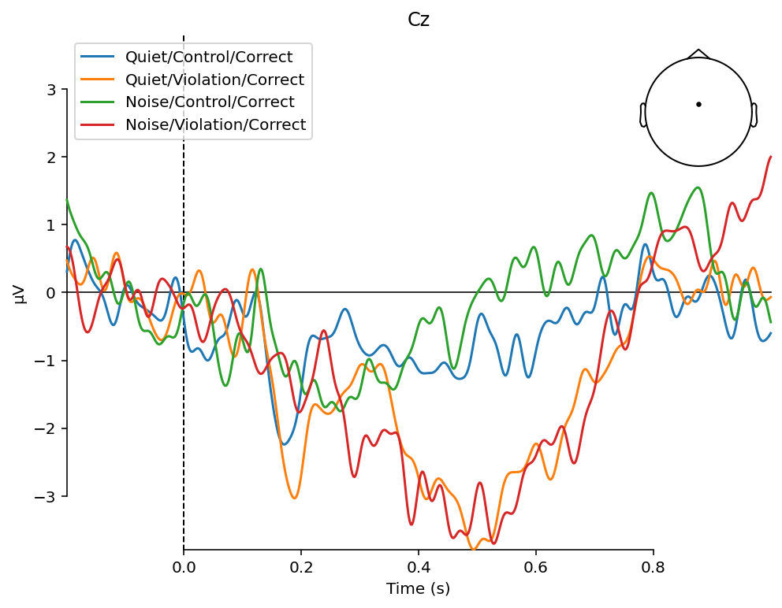

```python
Cz_idx = gavg['Quiet/Control/Correct'].ch_names.index('Cz')

mne.viz.plot_compare_evokeds(gavg, picks=Cz_idx)
plt.show()
```

## Topographic Maps

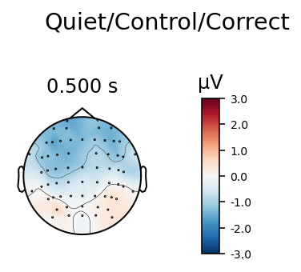

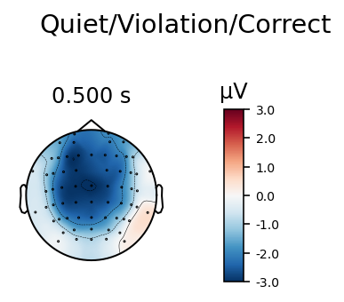

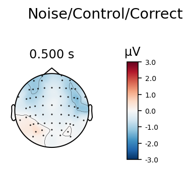

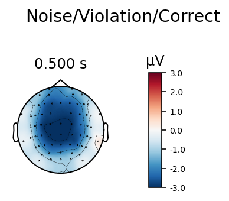

```python
# plot topographic maps for each of the four experimental conditions
for condition in gavg:
    gavg[condition].plot_topomap(.500, average=.200, vmin=-3, vmax=3, title = condition)
    plt.show()
```

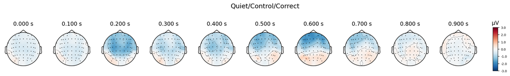

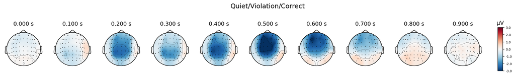

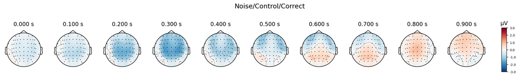

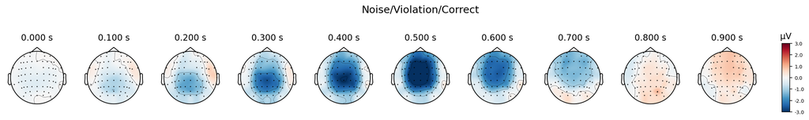

```python
# plot a series of time points
time = np.arange(0, 1.000, 0.100)

for condition in gavg:
    gavg[condition].plot_topomap(time, average=.100, vmin=-3, vmax=3, title=condition)
    plt.show()
```

## Difference Waves

```python
contrasts = {'Quiet_V-C' : ['Quiet/Violation/Correct', 'Quiet/Control/Correct'],
             'Noise_V-C' : ['Noise/Violation/Correct', 'Noise/Control/Correct']
            }
```

```python
gavg_diff = {}

for value in contrasts:
    gavg_diff[value] = mne.combine_evoked([gavg[contrasts[value][0]], -gavg[contrasts[value][1]]], weights='equal')

gavg_diff
```

```
{'Quiet_V-C': <Evoked | '0.500 × Grand average (n = 20) + 0.500 × -Grand average (n = 20)' (average, N=40.0), [-0.19922, 1] sec, 64 ch, ~479 kB>,
 'Noise_V-C': <Evoked | '0.500 × Grand average (n = 20) + 0.500 × -Grand average (n = 20)' (average, N=40.0), [-0.19922, 1] sec, 64 ch, ~479 kB>}
```

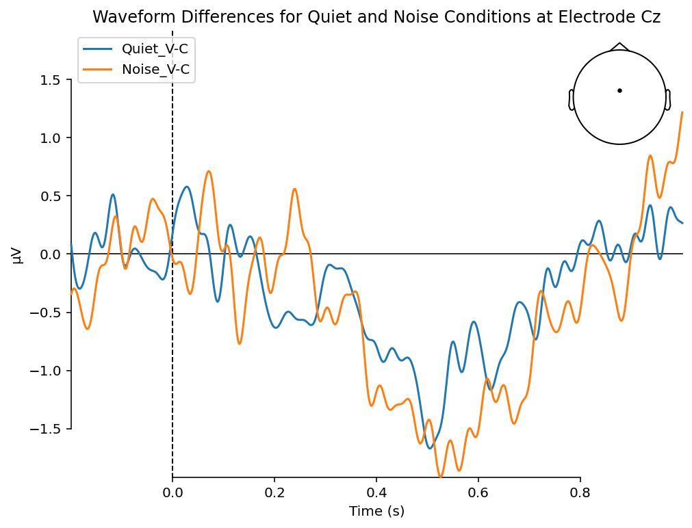

```python
# plot waveforms for the two differences at Cz
mne.viz.plot_compare_evokeds(gavg_diff, picks=Cz_idx, title = "Waveform Differences for Quiet and Noise Conditions at Electrode Cz")
plt.show()
```

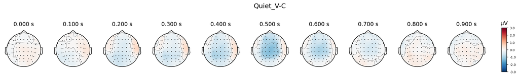

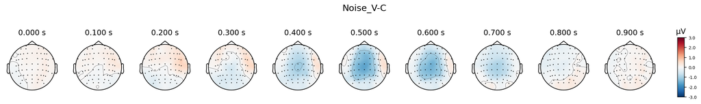

```python
# plot the difference waveforms
time = np.arange(0, 1.000, 0.100)

for condition in gavg_diff:
    gavg_diff[condition].plot_topomap(time, average=.100, vmin=-3, vmax=3, title=condition)
    plt.show()
```

Return to [homepage](https://noamaianski.github.io/portfolio/)